# 教師なし学習

## クラスタリング

### サンプルデータの準備

階層的クラスタリングをサンプルデータに適用してみる。このサンプルデータは、1000個の遺伝子の観測項目を持つ40個の細胞サンプルからなる遺伝子発現データセットである。

```r
dat = read.csv("Ch10Ex11.csv",header=F)
dat = t(dat)
dd = as.dist(1-cor(t(dat)))
```

### 連結方法の比較

今回は、完全連結法、平均連結法、単連結法の三つの連結方法で比較する。  
まず、完全連結法を試してみる。

```r
hc.complete=hclust(dd, method="complete")
print(table(predict=cutree(hc.complete, k=2),truth=c( rep(0,20), rep(1,20) )))
```

```
##        truth
## predict  0  1
##       1 10  0
##       2 10 20
```

結果は上のようになり、誤分類率は、(10+0)/40=0.25となる。  
次に、他の連結方法と比較してみる。

```r
hc.average=hclust(dd, method="average")
hc.single=hclust(dd, method="single")
```

```r
print(table(hc.average=cutree(hc.average, k=2),truth=c( rep(0,20), rep(1,20) )))
```

```
##           truth
## hc.average  0  1
##          1  9  0
##          2 11 20
```

平均連結法の結果は上のようになり、誤分類率は、0.275である。

```r
print(table(hc.single=cutree(hc.single, k=2),truth=c( rep(0,20), rep(1,20) )))
```

```
##          truth
## hc.single  0  1
##         1 19 20
##         2  1  0
```

単連結法の結果は上のようになり、誤分類率は0.475である。  
以上より、連結方法によって、分類の結果は変化し、今回のデータセットでは、完全連結法が最も精度が高くなった。 テンドログラム以下のようになる。

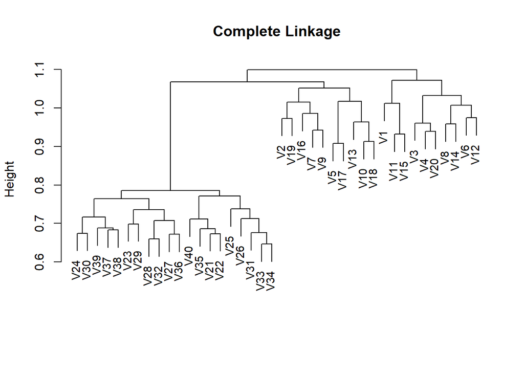

```r
plot(hc.complete,main="Complete Linkage", xlab="", sub="", cex=.9)
```

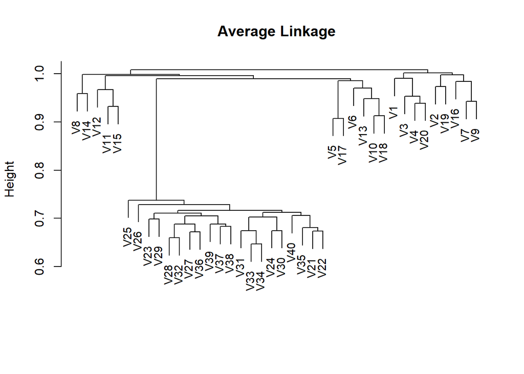

```r
plot(hc.average, main="Average Linkage", xlab="", sub="", cex=.9)
```

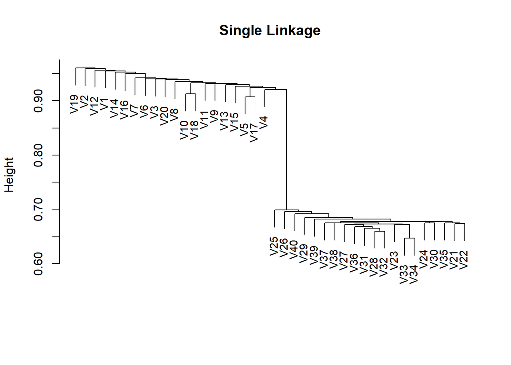

```r
plot(hc.single, main="Single Linkage", xlab="", sub="", cex=.9)
```

### 簡単な分析

2つのグループ間において最も異なる遺伝子を探す。  
今回は、2つのグループ間においてt値を出力する。

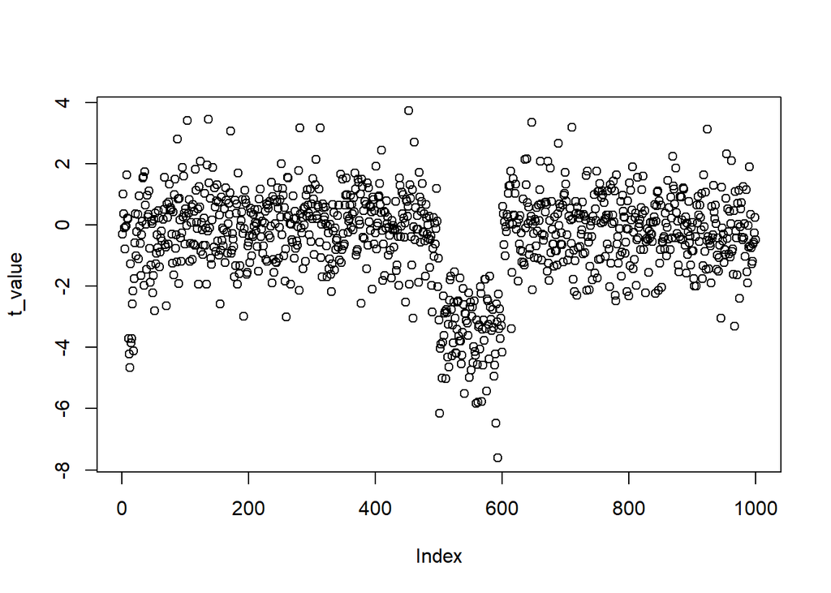

```r
predicted=cutree( hc.complete, k=2 )

n1 = apply( dat[ predicted==1, ], 2, length )
n2 = apply( dat[ predicted==2, ], 2, length )

m1 = apply( dat[ predicted==1, ], 2, mean )
m2 = apply( dat[ predicted==2, ], 2, mean )

v1 = apply( dat[ predicted==1, ], 2, var )
v2 = apply( dat[ predicted==2, ], 2, var )

pooled_variance = sqrt( v1 / n1 + v2 / n2 )

t_value = ( m1 - m2 ) / pooled_variance
plot(t_value)
```

以上より、インデックス500~600の遺伝子が最もt値の絶対値が大きいグループである。  
この中で最も絶対値が大きい遺伝子のインデックスとt値を求める。

```r
print(min(t_value))
```

```
## [1] -7.609456
```

```r
print(which.min(t_value))
```

```
## [1] 593
```

593番目の遺伝子が最もt値の絶対値が大きくなった。  
そこで、この遺伝子について2標本t検定(平均の差の検定)を行ってみる。 このデータは、母分散が未知で等しくないので、ウェルチの検定を適用する。

```r
g1=v1/n1
g2=v2/n2
f = (g1+g2)^2/(g1^2/(n1-1)+g2^2/(n2-1))
print(f[which.min(t_value)])
```

```
## [1] 32.10839
```

よって自由度は32となる。  
自由度30のときの下側2.5%点は-2.042、自由度40の時は-2.021であるから、仮説は棄却される。  
以上より、593番目の遺伝子が2つのグループ間で最も異なる遺伝子である。